# **1. About Dataset:**

- COVID-19 Dataset --> https://www.kaggle.com/datasets/meirnizri/covid19-dataset

[figure not shown]

## **i. Problem Statement:**

- The main goal of this project is to build a machine learning model that, given a Covid-19 patient's current symptom, status, and medical history, will **predict whether the patient is in high risk or not**.

## **ii. Features:**

- The dataset was provided by the Mexican government.
- The raw dataset consists of **21 unique features** and **1,048,576 unique patients**.
- In the Boolean features, **1** means "**yes**" and **2** means "**no**".
- Values as 97 and 99 are **missing data**.
  - **Sex**: female(1) or male(2)
  - **Age**: of the patient.
  - **Classification**: covid test findings.
    - Values 1-3 mean that the patient was **diagnosed** with covid in different degrees.
    - 4 or higher means that the patient is **not a carrier** of covid or that the test is inconclusive.
  - **Patient type**: hospitalized(1) or not hospitalized(2).
  - **Pneumonia**: Whether the patient already have air sacs inflammation(1) or not(2).
  - **Pregnancy**: Whether the patient is pregnant(1) or not(2).
  - **Diabetes**: Whether the patient has diabetes(1) or not(2).
  - **Copd**: Indicates whether the patient has Chronic obstructive pulmonary disease(1) or not(2).
  - **Asthma**: Whether the patient has asthma(1) or not(2).
  - **Inmsupr**: Whether the patient is immunosuppressed(1) or not(2).
  - **Hypertension**: Whether the patient has hypertension(1) or not(2).
  - **Cardiovascular**: Whether the patient has heart or blood vessels related disease(1) or not(2).
  - **Renal chronic**: Whether the patient has chronic renal disease(1) or not(2).
  - **Other disease**: Whether the patient has other disease(1) or not(2).
  - **Obesity**: Whether the patient is obese(1) or not(2).
  - **Tobacco**: Whether the patient is a tobacco(1) user or not(2).
  - **usmr**: Indicates Whether the patient treated medical units of the first, second or third level.
  - **Medical unit**: Type of institution of the National Health System that provided the care.
  - **Intubed**: Whether the patient was connected to the ventilator(1) or not(2).
  - **ICU**: Indicates whether the patient had been admitted to an Intensive Care Unit(1) or not(2).
  - **Date Died**: Indicates when the patient has died.

# **2. Data Exploration:**

```python
#!pip install matplotlib
```

```python
from google.colab import drive
drive.mount('/content/drive')
```

```python
import numpy as np
import pandas as pd
import matplotlib.pyplot as plt
import seaborn as sns

pd.set_option('display.max_columns', None)
pd.set_option('display.max_rows', 200)
```

```python
# Turn off warnings
import warnings
warnings.filterwarnings("ignore", category=FutureWarning)
```

```python
df = pd.read_csv('/content/drive/MyDrive/Tech4Dev/Databases/5. Machine Learning (ML)/Covid_Data.csv')
df
```

|  | USMER | MEDICAL_UNIT | SEX | PATIENT_TYPE | DATE_DIED | INTUBED | PNEUMONIA | AGE | PREGNANT | DIABETES | COPD | ASTHMA | INMSUPR | HIPERTENSION | OTHER_DISEASE | CARDIOVASCULAR | OBESITY | RENAL_CHRONIC | TOBACCO | CLASIFFICATION_FINAL | ICU |
| --- | --- | --- | --- | --- | --- | --- | --- | --- | --- | --- | --- | --- | --- | --- | --- | --- | --- | --- | --- | --- | --- |
| 0 | 2 | 1 | 1 | 1 | 03/05/2020 | 97 | 1 | 65 | 2 | 2 | 2 | 2 | 2 | 1 | 2 | 2 | 2 | 2 | 2 | 3 | 97 |
| 1 | 2 | 1 | 2 | 1 | 03/06/2020 | 97 | 1 | 72 | 97 | 2 | 2 | 2 | 2 | 1 | 2 | 2 | 1 | 1 | 2 | 5 | 97 |
| 2 | 2 | 1 | 2 | 2 | 09/06/2020 | 1 | 2 | 55 | 97 | 1 | 2 | 2 | 2 | 2 | 2 | 2 | 2 | 2 | 2 | 3 | 2 |
| 3 | 2 | 1 | 1 | 1 | 12/06/2020 | 97 | 2 | 53 | 2 | 2 | 2 | 2 | 2 | 2 | 2 | 2 | 2 | 2 | 2 | 7 | 97 |
| 4 | 2 | 1 | 2 | 1 | 21/06/2020 | 97 | 2 | 68 | 97 | 1 | 2 | 2 | 2 | 1 | 2 | 2 | 2 | 2 | 2 | 3 | 97 |
| ... | ... | ... | ... | ... | ... | ... | ... | ... | ... | ... | ... | ... | ... | ... | ... | ... | ... | ... | ... | ... | ... |
| 1048570 | 2 | 13 | 2 | 1 | 9999-99-99 | 97 | 2 | 40 | 97 | 2 | 2 | 2 | 2 | 2 | 2 | 2 | 2 | 2 | 2 | 7 | 97 |
| 1048571 | 1 | 13 | 2 | 2 | 9999-99-99 | 2 | 2 | 51 | 97 | 2 | 2 | 2 | 2 | 1 | 2 | 2 | 2 | 2 | 2 | 7 | 2 |
| 1048572 | 2 | 13 | 2 | 1 | 9999-99-99 | 97 | 2 | 55 | 97 | 2 | 2 | 2 | 2 | 2 | 2 | 2 | 2 | 2 | 2 | 7 | 97 |
| 1048573 | 2 | 13 | 2 | 1 | 9999-99-99 | 97 | 2 | 28 | 97 | 2 | 2 | 2 | 2 | 2 | 2 | 2 | 2 | 2 | 2 | 7 | 97 |
| 1048574 | 2 | 13 | 2 | 1 | 9999-99-99 | 97 | 2 | 52 | 97 | 2 | 2 | 2 | 2 | 2 | 2 | 2 | 2 | 2 | 2 | 7 | 97 |

1048575 rows × 21 columns

```python
df.info()
```

```
<class 'pandas.core.frame.DataFrame'>
RangeIndex: 1048575 entries, 0 to 1048574
Data columns (total 21 columns):
 #   Column                Non-Null Count    Dtype
---  ------                --------------    -----
 0   USMER                 1048575 non-null  int64
 1   MEDICAL_UNIT          1048575 non-null  int64
 2   SEX                   1048575 non-null  int64
 3   PATIENT_TYPE          1048575 non-null  int64
 4   DATE_DIED             1048575 non-null  object
 5   INTUBED               1048575 non-null  int64
 6   PNEUMONIA             1048575 non-null  int64
 7   AGE                   1048575 non-null  int64
 8   PREGNANT              1048575 non-null  int64
 9   DIABETES              1048575 non-null  int64
 10  COPD                  1048575 non-null  int64
 11  ASTHMA                1048575 non-null  int64
 12  INMSUPR               1048575 non-null  int64
 13  HIPERTENSION          1048575 non-null  int64
 14  OTHER_DISEASE         1048575 non-null  int64
 15  CARDIOVASCULAR        1048575 non-null  int64
 16  OBESITY               1048575 non-null  int64
 17  RENAL_CHRONIC         1048575 non-null  int64
 18  TOBACCO               1048575 non-null  int64
 19  CLASIFFICATION_FINAL  1048575 non-null  int64
 20  ICU                   1048575 non-null  int64
dtypes: int64(20), object(1)
memory usage: 168.0+ MB
```

```python
# From the description of dataset, null values are replaced with 97 or 99
# This is a double check
df.isnull().sum()
```

```
USMER                   0
MEDICAL_UNIT            0
SEX                     0
PATIENT_TYPE            0
DATE_DIED               0
INTUBED                 0
PNEUMONIA               0
AGE                     0
PREGNANT                0
DIABETES                0
COPD                    0
ASTHMA                  0
INMSUPR                 0
HIPERTENSION            0
OTHER_DISEASE           0
CARDIOVASCULAR          0
OBESITY                 0
RENAL_CHRONIC           0
TOBACCO                 0
CLASIFFICATION_FINAL    0
ICU                     0
dtype: int64
```

```python
# Check Cardinality in Categorical Features

selected_columns = df.columns.drop(['AGE','DATE_DIED'])

unique_dic = []

for col in selected_columns:

  unique_num = len(df[col].unique())
  unique_dic.append({'Total_Unique' : unique_num,
                     'Cardinality%': (unique_num/1048575)*100})

unique_df = pd.DataFrame(unique_dic, index = selected_columns).sort_values(by = 'Cardinality%', ascending = False)
unique_df
```

|  | Total_Unique | Cardinality% |
| --- | --- | --- |
| MEDICAL_UNIT | 13 | 0.001240 |
| CLASIFFICATION_FINAL | 7 | 0.000668 |
| ICU | 4 | 0.000381 |
| INTUBED | 4 | 0.000381 |
| PREGNANT | 4 | 0.000381 |
| HIPERTENSION | 3 | 0.000286 |
| TOBACCO | 3 | 0.000286 |
| RENAL_CHRONIC | 3 | 0.000286 |
| OBESITY | 3 | 0.000286 |
| CARDIOVASCULAR | 3 | 0.000286 |
| OTHER_DISEASE | 3 | 0.000286 |
| ASTHMA | 3 | 0.000286 |
| INMSUPR | 3 | 0.000286 |
| COPD | 3 | 0.000286 |
| DIABETES | 3 | 0.000286 |
| PNEUMONIA | 3 | 0.000286 |
| PATIENT_TYPE | 2 | 0.000191 |
| SEX | 2 | 0.000191 |
| USMER | 2 | 0.000191 |

```python
# Check unique values for each feature

selected_columns = df.columns.drop('AGE')

for column in selected_columns:
    print('\n*-*-*-*-*-*\n')
    print(pd.DataFrame(df[column].value_counts()))
```

```
*-*-*-*-*-*

    USMER
2  662903
1  385672

*-*-*-*-*-*

    MEDICAL_UNIT
12        602995
4         314405
6          40584
9          38116
3          19175
8          10399
10          7873
5           7244
11          5577
13           996
7            891
2            169
1            151

*-*-*-*-*-*

      SEX
1  525064
2  523511

*-*-*-*-*-*

   PATIENT_TYPE
1        848544
2        200031

*-*-*-*-*-*

            DATE_DIED
9999-99-99     971633
06/07/2020       1000
```

[output cut: 108 more lines]

```
7                499250
3                381527
6                128133
5                 26091
1                  8601
4                  3122
2                  1851

*-*-*-*-*-*

       ICU
97  848544
2   175685
1    16858
99    7488
```

```python
# Check age (continous data) description
# Minimum = 0, Maximum = 121, Median = 40
df.AGE.describe()
```

```
count    1.048575e+06
mean     4.179410e+01
std      1.690739e+01
min      0.000000e+00
25%      3.000000e+01
50%      4.000000e+01
75%      5.300000e+01
max      1.210000e+02
Name: AGE, dtype: float64
```

```python
# We have 138 patient with age > 100 ie. 0.013% of our dataset

df[df.AGE > 100].AGE.count()
```

```
138
```

**- Features with no null values:**

- Sex
- Age
- Classification
- Medical unit
- Patient type
- usmr

**- Features with null values:**

- Pneumonia: 99 = 16003
- Diabetes: 98 = 3338
- Copd: 98 = 3003
- Asthma: 98 = 2979
- Inmsupr: 98 = 3404
- Hypertension: 98 = 3104
- Cardiovascular: 98 = 3076
- Renal chronic: 98 = 3006
- Other disease: 98 = 5045
- Obesity: 98 = 3032
- Tobacco: 98 = 3220
- Null values ranges from 3000 - 16000 ie. (0.2 - 1.5 % of total dataset)
- The highest number (16000) in pneumonea may be explained by the shoratge of radiological investigations.
- Being a categorical features, we will replace these missed data with the (Mode).

**- Features that show more than one type of null values:**

- **Pregnancy: '97' = 523511, '98' = 3754**
  - We noticed that '97' count is = male count in our dataset
  - Sex: '2' = 523511
- **Intubed: '97' = 848544, '99' = 7325**
  - We noticed that '97' count is = hospitalized count in our dataset
  - Patient type: '1' = 848544
- **ICU: '97' = 848544, '99' = 7488**
  - We noticed that '97' count is = hospitalized count in our dataset
  - Patient type: '1' = 848544
- For pregnant category, males can't either be pregnant or not pregnant that why it appears like a null values, we will change the 97 values to 2 (non-pregnant), and fill the 98 with the mode.
- Applying the same concept to being in ICU or intubated, patient should be hospitalized. non hospitalized can't either be in ICU or not, or intubated or not.
- We think that the labeling of patient type is wrong, 1 should be for non hospitalized , 2 for hospitalized.

Visualization will confirm our opinion about these different null vlaues.

- **Date Died:**
  - We can see that most of data are (9999-99-99), ie. having no death date, the count of this value = 971633 ie. 92% of dataset, it can't be just dropped.
  - So we considered this date as recovery ie. no death which is convinent as across the world, most patients recovered, this will be our label.
  - This also means that our dataset is imbalanced.
  - For **imbalance** we could use:
    - oversampling techniques, buy due to the very large dataset (1 Million), we can't use it.
    - Undersamping techniques resulted in very very low scores.
- **Classification:**
  - in our model, we will keep classes (1,2,3) as it is, cause it reflects the degree of infection, while changing all classes >= 4 into 0
  - We will make column of (covid Vs non covid) only for visualization

```python
# Check gender type when pregnancy = 97
# Gender = 2 ie. male

pregnant_male = df[df.PREGNANT == 97]
pregnant_male.SEX.value_counts()
```

```
2    523511
Name: SEX, dtype: int64
```

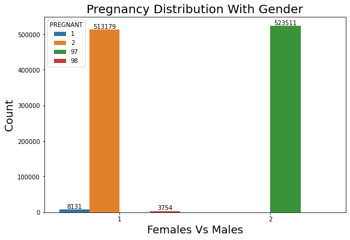

```python
# Count plot to figure out the different categories of pregnancy across gender.

plt.figure(figsize = (9,6))
ax = sns.countplot(df.SEX, hue = df.PREGNANT)
for bars in ax.containers:
    ax.bar_label(bars)

plt.ylabel('Count', size = 18)
plt.xlabel('Females Vs Males', size = 18)
plt.title('Pregnancy Distribution With Gender', fontsize = 20);
```

```python
# Check patient type when intubation = 97
# Patient type = 1 ie. (Hospitalized)

intubed_type = df[df.INTUBED == 97]
intubed_type.PATIENT_TYPE.value_counts()
```

```
1    848544
Name: PATIENT_TYPE, dtype: int64
```

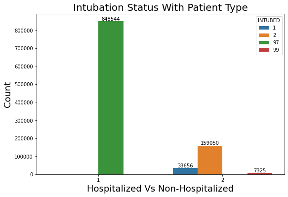

```python
# Count plot to figure out intubation among differnt patients (Hospitalized Vs Non-hospitalized)

plt.figure(figsize = (9,6))
ax = sns.countplot(df.PATIENT_TYPE, hue = df.INTUBED)
for bars in ax.containers:
    ax.bar_label(bars)

plt.ylabel('Count', size = 18)
plt.xlabel('Hospitalized Vs Non-Hospitalized', size = 18)
plt.title('Intubation Status With Patient Type', fontsize = 20);
```

```python
# Check patient type when ICU = 97
# Patient type = 1 ie. (Hospitalized)

icu_type = df[df.ICU == 97]
icu_type.PATIENT_TYPE.value_counts()
```

```
1    848544
Name: PATIENT_TYPE, dtype: int64
```

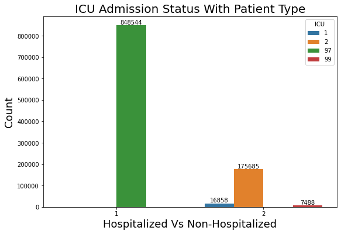

```python
# Count plot to figure out ICU admission among differnt patients (Hospitalized Vs Non-hospitalized)

plt.figure(figsize = (9,6))
ax = sns.countplot(df.PATIENT_TYPE, hue = df.ICU)
for bars in ax.containers:
    ax.bar_label(bars)

plt.ylabel('Count', size = 18)
plt.xlabel('Hospitalized Vs Non-Hospitalized', size = 18)
plt.title('ICU Admission Status With Patient Type', fontsize = 20);
```

**These graphs confirms our insights that:**

- Pregnant = 97 is when patient is male
- Intubed = 97 is when patient is hospitalized
- ICU = 97 is when patient is hospitalized

For 'INTUBED', 'ICU': It seems that the labeling of patient type in dataset description is wrong, as non hospitalized can't be in ICU or Intubated as shown in graph.

This means that datapoints where patient type = 1 is actually non-hospitalized patients and that's why their data is '97 ie. Null' as as non hospitalized can't be in ICU or Intubated as shown in graph.

This is further supported by the argument that most COVID-19 patients do not require an ICU.

--> will Create new column for patient type with the correct labeling.

# **3. Data Cleaning:**

### **b. PREGNANT:**

```python
# Replace '97' in pregnant with '2' ie. when gender = male, pregnant = 2
# So that SEX and PREGNANT are independent variables.

df.PREGNANT = df.PREGNANT.replace(97, 2)
df.PREGNANT.value_counts()
```

```
2     1036690
1        8131
98       3754
Name: PREGNANT, dtype: int64
```

### **c. PATIENT_TYPE:**

```python
# Creating new column (PATIENT_HOSP) to correct the definitions
# PATIENT_HOSP = 1 (Hospitalized)
# PATIENT_HOSP = 1 (Non_hospitalized)

def change_type(val):
    if val == 1:
        return 2
    elif val == 2 :
        return 1


df['PATIENT_HOSP'] = df['PATIENT_TYPE'].map(change_type)

df.head()
```

|  | USMER | MEDICAL_UNIT | SEX | PATIENT_TYPE | DATE_DIED | INTUBED | PNEUMONIA | AGE | PREGNANT | DIABETES | COPD | ASTHMA | INMSUPR | HIPERTENSION | OTHER_DISEASE | CARDIOVASCULAR | OBESITY | RENAL_CHRONIC | TOBACCO | CLASIFFICATION_FINAL | ICU | PATIENT_HOSP |
| --- | --- | --- | --- | --- | --- | --- | --- | --- | --- | --- | --- | --- | --- | --- | --- | --- | --- | --- | --- | --- | --- | --- |
| 0 | 2 | 1 | 1 | 1 | 03/05/2020 | 97 | 1 | 65 | 2 | 2 | 2 | 2 | 2 | 1 | 2 | 2 | 2 | 2 | 2 | 3 | 97 | 2 |
| 1 | 2 | 1 | 2 | 1 | 03/06/2020 | 97 | 1 | 72 | 2 | 2 | 2 | 2 | 2 | 1 | 2 | 2 | 1 | 1 | 2 | 5 | 97 | 2 |
| 2 | 2 | 1 | 2 | 2 | 09/06/2020 | 1 | 2 | 55 | 2 | 1 | 2 | 2 | 2 | 2 | 2 | 2 | 2 | 2 | 2 | 3 | 2 | 1 |
| 3 | 2 | 1 | 1 | 1 | 12/06/2020 | 97 | 2 | 53 | 2 | 2 | 2 | 2 | 2 | 2 | 2 | 2 | 2 | 2 | 2 | 7 | 97 | 2 |
| 4 | 2 | 1 | 2 | 1 | 21/06/2020 | 97 | 2 | 68 | 2 | 1 | 2 | 2 | 2 | 1 | 2 | 2 | 2 | 2 | 2 | 3 | 97 | 2 |

```python
df = df.drop('PATIENT_TYPE', axis = 1)
```

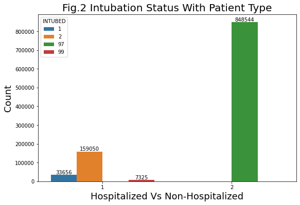

```python
# Ensure correct definnition of patient type

plt.figure(figsize = (9,6))
ax = sns.countplot(df.PATIENT_HOSP, hue = df.INTUBED)
for bars in ax.containers:
    ax.bar_label(bars)

plt.ylabel('Count', size = 18)
plt.xlabel('Hospitalized Vs Non-Hospitalized', size = 18)
plt.title('Fig.2 Intubation Status With Patient Type', fontsize = 20);
```

### **d. INTUBED:**

```python
# Replace '97' in Intubed with '2' ie. when patient not hospitalized, intubed = 2 (not-intubated)

df.INTUBED = df.INTUBED.replace(97, 2)
df.INTUBED.value_counts()
```

```
2     1007594
1       33656
99       7325
Name: INTUBED, dtype: int64
```

### **e. ICU**:

```python
# Replace '97' in ICU with '2' ie. when patient not hospitalized, intubed = 2 (not in ICU)

df.ICU = df.ICU.replace(97, 2)
df.ICU.value_counts()
```

```
2     1024229
1       16858
99       7488
Name: ICU, dtype: int64
```

### **f. CLASSIFICATION_FINAL**:

**- Classification:** covid test findings.

- Values 1-3 mean that the patient was diagnosed with covid in different degrees.
- 4 or higher means that the patient is not a carrier of covid or that the test is inconclusive.
- We will convert classes of >= 4 to 0 (No-covid), keeping (1,2,3) as it is. (Ordinal Data)

```python
df.CLASIFFICATION_FINAL.value_counts()
```

```
7    499250
3    381527
6    128133
5     26091
1      8601
4      3122
2      1851
Name: CLASIFFICATION_FINAL, dtype: int64
```

```python
# Replacing the non-covid patients with 0

df.CLASIFFICATION_FINAL = df.CLASIFFICATION_FINAL.replace([4,5,6,7], 0)
df.CLASIFFICATION_FINAL.value_counts()
```

```
0    656596
3    381527
1      8601
2      1851
Name: CLASIFFICATION_FINAL, dtype: int64
```

```python
# Creating new column for covid of Covid (1) , Non-covid (2) for visualization


def covid_diagnosis(val):
    if val == 0:
        return 2
    else :
        return 1


df['COVID'] = df['CLASIFFICATION_FINAL'].map(covid_diagnosis)

df.head()
```

|  | USMER | MEDICAL_UNIT | SEX | DATE_DIED | INTUBED | PNEUMONIA | AGE | PREGNANT | DIABETES | COPD | ASTHMA | INMSUPR | HIPERTENSION | OTHER_DISEASE | CARDIOVASCULAR | OBESITY | RENAL_CHRONIC | TOBACCO | CLASIFFICATION_FINAL | ICU | PATIENT_HOSP | COVID |
| --- | --- | --- | --- | --- | --- | --- | --- | --- | --- | --- | --- | --- | --- | --- | --- | --- | --- | --- | --- | --- | --- | --- |
| 0 | 2 | 1 | 1 | 03/05/2020 | 2 | 1 | 65 | 2 | 2 | 2 | 2 | 2 | 1 | 2 | 2 | 2 | 2 | 2 | 3 | 2 | 2 | 1 |
| 1 | 2 | 1 | 2 | 03/06/2020 | 2 | 1 | 72 | 2 | 2 | 2 | 2 | 2 | 1 | 2 | 2 | 1 | 1 | 2 | 0 | 2 | 2 | 2 |
| 2 | 2 | 1 | 2 | 09/06/2020 | 1 | 2 | 55 | 2 | 1 | 2 | 2 | 2 | 2 | 2 | 2 | 2 | 2 | 2 | 3 | 2 | 1 | 1 |
| 3 | 2 | 1 | 1 | 12/06/2020 | 2 | 2 | 53 | 2 | 2 | 2 | 2 | 2 | 2 | 2 | 2 | 2 | 2 | 2 | 0 | 2 | 2 | 2 |
| 4 | 2 | 1 | 2 | 21/06/2020 | 2 | 2 | 68 | 2 | 1 | 2 | 2 | 2 | 1 | 2 | 2 | 2 | 2 | 2 | 3 | 2 | 2 | 1 |

```python
df.COVID.value_counts()
```

```
2    656596
1    391979
Name: COVID, dtype: int64
```